# Part I - Ford GoBike System Dataset Exploration

## Introduction

> The Ford GoBike System Data is a dataset that includes information about individual rides made in a bike-sharing system covering the greater San Francisco Bay area. The dataset provides valuable insights into the usage patterns, trip durations, and user characteristics of the bike-sharing system.

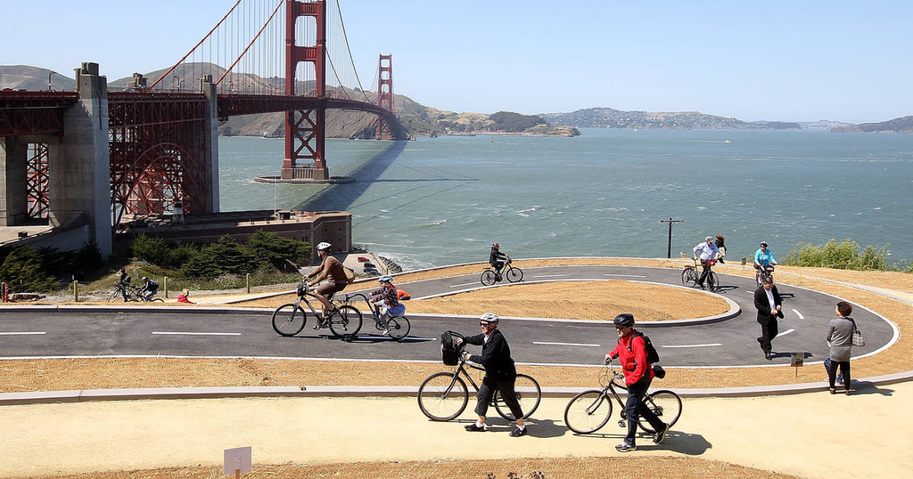

# Preliminary Wrangling

```python
# import all packages and set plots to be embedded inline
import numpy as np
import pandas as pd
import matplotlib.pyplot as plt
import seaborn as sb

%matplotlib inline
```

```python
# Load the dataset
df = pd.read_csv("201902-fordgobike-tripdata.csv")
```

```python
# Display the first few rows of the DataFrame
df.head(5)
```

[output not shown]

```python
# Display information about the dataset, including column names and data types
df.info()
```

```
<class 'pandas.core.frame.DataFrame'>
RangeIndex: 183412 entries, 0 to 183411
Data columns (total 16 columns):
 #   Column                   Non-Null Count   Dtype
---  ------                   --------------   -----
 0   duration_sec             183412 non-null  int64
 1   start_time               183412 non-null  object
 2   end_time                 183412 non-null  object
 3   start_station_id         183215 non-null  float64
 4   start_station_name       183215 non-null  object
 5   start_station_latitude   183412 non-null  float64
 6   start_station_longitude  183412 non-null  float64
 7   end_station_id           183215 non-null  float64
 8   end_station_name         183215 non-null  object
 9   end_station_latitude     183412 non-null  float64
 10  end_station_longitude    183412 non-null  float64
 11  bike_id                  183412 non-null  int64
 12  user_type                183412 non-null  object
 13  member_birth_year        175147 non-null  float64
 14  member_gender            175147 non-null  object
 15  bike_share_for_all_trip  183412 non-null  object
dtypes: float64(7), int64(2), object(7)
memory usage: 17.5+ MB
```

> After careful consideration, I have decided to drop the rows with missing values in the member_birth_year and member_gender columns. These missing values account for a small proportion of the dataset, and I believe that maintaining accuracy in the analysis is crucial. By dropping these rows, I ensure that the remaining data used for analysis is complete and reliable.

```python
#Dropping missing values in member_birth_year and member_gender
df.dropna(subset=['member_birth_year', 'member_gender'], inplace=True)
```

Same for these rows which has missing values in end station and start station columns

```python
# Drop rows with missing values in end station and start station columns
df.dropna(subset=['end_station_id', 'end_station_name', 'start_station_id', 'start_station_name'], inplace=True)
```

```python
# After dropping some values, Check for missing values in the dataset:
print(df.isnull().sum())
```

```
duration_sec               0
start_time                 0
end_time                   0
start_station_id           0
start_station_name         0
start_station_latitude     0
start_station_longitude    0
end_station_id             0
end_station_name           0
end_station_latitude       0
end_station_longitude      0
bike_id                    0
user_type                  0
member_birth_year          0
member_gender              0
bike_share_for_all_trip    0
dtype: int64
```

Good now we don't have missing values, we can continue our job.

After dropping values, now I will start to get into the dataset by calling some functions

```python
#Get the shape of the dataset (number of rows and columns):

print(df.shape)
```

```
(174952, 16)
```

```python
#Get the column names:

print(df.columns)
```

```
Index(['duration_sec', 'start_time', 'end_time', 'start_station_id',
       'start_station_name', 'start_station_latitude',
       'start_station_longitude', 'end_station_id', 'end_station_name',
       'end_station_latitude', 'end_station_longitude', 'bike_id', 'user_type',
       'member_birth_year', 'member_gender', 'bike_share_for_all_trip'],
      dtype='object')
```

```python
# Display summary statistics of the numerical columns
df.describe()
```

|  | duration_sec | start_station_id | start_station_latitude | start_station_longitude | end_station_id | end_station_latitude | end_station_longitude | bike_id | member_birth_year |
| --- | --- | --- | --- | --- | --- | --- | --- | --- | --- |
| count | 174952.000000 | 174952.000000 | 174952.000000 | 174952.000000 | 174952.000000 | 174952.000000 | 174952.000000 | 174952.000000 | 174952.000000 |
| mean | 704.002744 | 139.002126 | 37.771220 | -122.351760 | 136.604486 | 37.771414 | -122.351335 | 4482.587555 | 1984.803135 |
| std | 1642.204905 | 111.648819 | 0.100391 | 0.117732 | 111.335635 | 0.100295 | 0.117294 | 1659.195937 | 10.118731 |
| min | 61.000000 | 3.000000 | 37.317298 | -122.453704 | 3.000000 | 37.317298 | -122.453704 | 11.000000 | 1878.000000 |
| 25% | 323.000000 | 47.000000 | 37.770407 | -122.411901 | 44.000000 | 37.770407 | -122.411647 | 3799.000000 | 1980.000000 |
| 50% | 510.000000 | 104.000000 | 37.780760 | -122.398279 | 101.000000 | 37.781010 | -122.397437 | 4960.000000 | 1987.000000 |
| 75% | 789.000000 | 239.000000 | 37.797320 | -122.283093 | 238.000000 | 37.797673 | -122.286533 | 5505.000000 | 1992.000000 |
| max | 84548.000000 | 398.000000 | 37.880222 | -121.874119 | 398.000000 | 37.880222 | -121.874119 | 6645.000000 | 2001.000000 |

> After dropping the missing values, I noticed that the summary statistics of the dataset have changed slightly. I expected this because the dropped rows had missing values in certain columns, which can affect calculations such as mean, standard deviation, and quartiles.

> Although there are minor changes in the summary statistics, it is not a significant issue. Since the dropped rows represent a small portion of the total dataset, the impact on the overall analysis is minimal. The remaining data still provides valuable insights and can be used for meaningful analysis.

> I made the decision to drop missing values in order to ensure the accuracy and integrity of my analysis. By removing incomplete or unreliable data points, I can focus on a more complete and representative subset of the dataset, which leads to more reliable conclusions and insights.

> Overall, I believe that the slight changes in the summary statistics after dropping missing values are acceptable and do not compromise the validity of my analysis.

From the table above, `duration_sec` and `member_birth_year` are important.

```python
#Get the data types of each column:

print(df.dtypes)
```

```
duration_sec                 int64
start_time                  object
end_time                    object
start_station_id           float64
start_station_name          object
start_station_latitude     float64
start_station_longitude    float64
end_station_id             float64
end_station_name            object
end_station_latitude       float64
end_station_longitude      float64
bike_id                      int64
user_type                   object
member_birth_year          float64
member_gender               object
bike_share_for_all_trip     object
dtype: object
```

We convert the 'start_time' and 'end_time' columns to the datetime data type using the pd.to_datetime() function. This will allow us to easily work with time-related data and perform various time-based operations.

```python
# Convert 'start_time' and 'end_time' columns to datetime
df['start_time'] = pd.to_datetime(df['start_time'])
df['end_time'] = pd.to_datetime(df['end_time'])
```

We convert the `start_station_id` and `nd_station_id`columns to the int64 data type using the astype() method. This change was made because station IDs are typically represented as integers, and using the int64 data type allows for more efficient storage and supports integer-based operations.

```python
# Convert 'start_station_id' and 'end_station_id' columns to int
df['start_station_id'] = df['start_station_id'].astype(int)
df['end_station_id'] = df['end_station_id'].astype(int)
```

- Printing the unique values in the `user_type` column allows us to see the different types of users in the bike-sharing system.
- Printing the unique values in the `member_gender` column helps us understand the distribution of gender among the users.
- Printing the unique values in the `bike_share_for_all_trip` column provides insights into whether users share bikes for all their trips or not.

```python
# Looping through columns to print unique values
columns = ['user_type', 'member_gender', 'bike_share_for_all_trip']
for column in columns:
    print(df[column].unique())
```

```
['Customer' 'Subscriber']
['Male' 'Other' 'Female']
['No' 'Yes']
```

This code will provide the count of unique values in the `user_type` column, which helps in understanding the proportion of subscribers and customers in the bike-sharing system.

```python
# Get the count of each unique value in the 'user_type' column
print(df['user_type'].value_counts())
```

```
Subscriber    158386
Customer       16566
Name: user_type, dtype: int64
```

> You can see that subscribers are ten times bigger than customers

This code will display the count of unique values in the `member_gender` column, giving insights into the gender distribution among the users. It helps identify the dominant gender among the users.

```python
# Display the count of each unique value in the 'member_gender' column
print(df['member_gender'].value_counts())
```

```
Male      130500
Female     40805
Other       3647
Name: member_gender, dtype: int64
```

> Indeed, from the available data, it appears that there is a higher proportion of male users compared to female and other genders in the bike-sharing system in the San Francisco Bay area. The count of male users is significantly higher (130,500) compared to female users (40,805) and users with other genders (3,647). This suggests that the bike-sharing system is more popular among male riders.

By using this code, we can get the count of unique values in the `bike_share_for_all_trip` column. It helps determine the frequency of users who share their bikes for the entire trip ('Yes') compared to those who don't ('No').

```python
# Show the count of each unique value in the 'bike_share_for_all_trip' column
print(df['bike_share_for_all_trip'].value_counts())
```

```
No     157606
Yes     17346
Name: bike_share_for_all_trip, dtype: int64
```

```python
# Define the function to print value counts
def print_value_counts(column):
    value_counts = df[column].value_counts()
    print(value_counts)

print("Value counts of the 'start_station_id' column")
print_value_counts('start_station_id')
print("\n")

print("Value counts of the 'end_station_id' column")
print_value_counts('end_station_id')
print("\n")

print("Value counts of the 'start_station_name' column")
print_value_counts('start_station_name')
print("\n")

print("Value counts of the 'end_station_name' column")
print_value_counts('end_station_name')
print("\n")
```

```
Value counts of the 'start_station_id' column
58     3649
67     3408
81     2952
21     2711
3      2620
       ...
234       9
51        7
224       4
300       3
344       2
Name: start_station_id, Length: 329, dtype: int64


Value counts of the 'end_station_id' column
67     4624
58     3709
21     3461
15     3151
30     2870
       ...
51        9
300       7
344       6
301       5
224       5
Name: end_station_id, Length: 329, dtype: int64


Value counts of the 'start_station_name' column
Market St at 10th St                                         3649
San Francisco Caltrain Station 2  (Townsend St at 4th St)    3408
Berry St at 4th St                                           2952
Montgomery St BART Station (Market St at 2nd St)             2711
Powell St BART Station (Market St at 4th St)                 2620
                                                             ...
Farnam St at Fruitvale Ave                                      9
Parker Ave at McAllister St                                     7
21st Ave at International Blvd                                  4
Palm St at Willow St                                            3
16th St Depot                                                   2
Name: start_station_name, Length: 329, dtype: int64


Value counts of the 'end_station_name' column
San Francisco Caltrain Station 2  (Townsend St at 4th St)    4624
Market St at 10th St                                         3709
Montgomery St BART Station (Market St at 2nd St)             3461
San Francisco Ferry Building (Harry Bridges Plaza)           3151
San Francisco Caltrain (Townsend St at 4th St)               2870
                                                             ...
Parker Ave at McAllister St                                     9
Palm St at Willow St                                            7
16th St Depot                                                   6
Willow St at Vine St                                            5
21st Ave at International Blvd                                  5
Name: end_station_name, Length: 329, dtype: int64
```

### What is the structure of your dataset?

### Dataset Structure

After dropping the missing values, the dataset now consists of 174,952 rows and 16 columns. Each row represents an individual ride made in the bike-sharing system covering the greater San Francisco Bay area. The dataset includes the following columns:

- `duration_sec`: The duration of the ride in seconds (numeric)
- `start_time`: The start time of the ride (datetime)
- `end_time`: The end time of the ride (datetime)
- `start_station_id`: The ID of the start station (numeric)
- `start_station_name`: The name of the start station (string)
- `start_station_latitude`: The latitude of the start station (numeric)
- `start_station_longitude`: The longitude of the start station (numeric)
- `end_station_id`: The ID of the end station (numeric)
- `end_station_name`: The name of the end station (string)
- `end_station_latitude`: The latitude of the end station (numeric)
- `end_station_longitude`: The longitude of the end station (numeric)
- `bike_id`: The ID of the bike used for the ride (numeric)
- `user_type`: The type of user (either "Customer" or "Subscriber")
- `member_birth_year`: The birth year of the user (numeric)
- `member_gender`: The gender of the user (either "Male", "Female", or "Other")
- `bike_share_for_all_trip`: Indicates whether the user shared the bike for the entire trip (either "Yes" or "No")

This structure provides an overview of the columns and their respective data types, which will be useful for analyzing and visualizing the data.

### What is/are the main feature(s) of interest in your dataset?

## Main Features of Interest

From my perspective, the main features of interest in the dataset are as follows:

1. **Start Station ID and Name:** The unique values in the `start_station_id` and `start_station_name` columns provide insights into the starting point of the bike rides. By examining the count of unique values in these columns, we can identify the most frequently used start stations. For example, the station with ID **58** has the highest count of **3,649** rides, followed by station **67** with **3,408** rides. Understanding popular start stations helps in analyzing user preferences and planning station infrastructure.
2. **End Station ID and Name:** Similarly, the unique values in the `end_station_id` and `end_station_name` columns give us information about the destination of the bike rides. By analyzing the count of unique values, we can identify the most commonly used end stations. For instance, the station with ID **67** has the highest count of **4,624** rides, followed by station **58** with **3,709** rides. This helps us understand popular destinations and can be useful for station planning and optimizing bike availability.
3. **User Type:** The unique values in the `user_type` column provide insights into the types of users in the bike-sharing system. By examining the count of unique values, we can determine the proportion of subscribers and customers. In our dataset, there are **158,386** subscribers and **16,566** customers. This information helps us understand the user base and tailor services accordingly.
4. **Member Gender:** The unique values in the `member_gender` column give insights into the gender distribution among the users. By analyzing the count of unique values, we find that there are **130,500** male users, **40,805** female users, and **3,647** users with other genders. Understanding the gender distribution helps in designing targeted marketing campaigns and identifying any gender-based patterns or preferences.
5. **Bike Share for All Trip:** The unique values in the `bike_share_for_all_trip` column provide insights into whether users share their bikes for the entire trip or not. By examining the count of unique values, we find that the majority of users (**157,606**) do not share their bikes for the entire trip, while a smaller portion (**17,346**) do. This information helps in understanding the level of bike sharing and its impact on trip durations and bike availability.

These features provide insights into the usage patterns, popular routes, user preferences, and demographic distribution within the bike-sharing system. Analyzing start and end stations helps in identifying demand patterns, optimizing station locations, and improving the overall user experience. Additionally, understanding user types, gender distribution, and bike sharing behavior helps in tailoring services and marketing strategies to meet user needs and preferences.

### What features in the dataset do you think will help support your investigation into your feature(s) of interest?

## Features for Investigation

As I investigate the dataset and explore my features of interest, I believe the following features will be instrumental in supporting my analysis:

1. **Duration_sec**: The duration of the ride will provide me with valuable insights into the length of time users spend on their bike rides. Analyzing ride durations will help me identify patterns, outliers, and the impact of ride duration on other variables.
2. **Start_time** and **End_time**: These columns capture the start and end times of the rides. By examining the temporal patterns, I can uncover peak usage hours, daily or weekly trends, and potential seasonality in bike usage.
3. **Start_station_id** and **End_station_id**: These unique identifiers for the start and end stations will enable me to analyze station-specific data. I can identify popular or frequently used stations and understand the patterns of bike rides from one station to another.
4. **User_type**: By categorizing users as either "Customer" or "Subscriber," I can analyze the behavior and preferences of different user groups. This will allow me to compare ride durations, frequencies, and usage patterns between customers and subscribers.
5. **Member_birth_year** and **Member_gender**: These demographic columns provide insights into the age and gender distribution of users. Analyzing these factors will help me identify age-related patterns, gender-based differences in bike usage, and the preferences of different user segments.
6. **Bike_share_for_all_trip**: This column indicates whether the user shared the bike for the entire trip or not. Analyzing this feature will provide insights into the prevalence and impact of bike sharing within the bike-sharing system.
7. **Start_date**: By extracting the dates from the 'start_time' column, I can further analyze the temporal patterns of bike usage. This will allow me to identify popular months, weekly usage patterns, and determine the influence of seasons on bike usage.

By exploring and analyzing these features, I will gain a comprehensive understanding of user behavior, preferences, temporal trends, station-specific patterns, and the impact of bike sharing in the bike-sharing system.

To support my investigation, I will employ data visualization techniques. Visualizing the start time and other relevant features will enable me to effectively communicate and interpret the patterns and trends in the dataset. This visual exploration will enhance my understanding of the data and assist in uncovering meaningful insights.

Throughout the analysis, I will strive to gain insights into the factors that drive bike-sharing usage, understand user preferences, and identify potential opportunities for improving the bike-sharing system.

# Univariate Exploration

### Question 1: What is the distribution of ride durations?

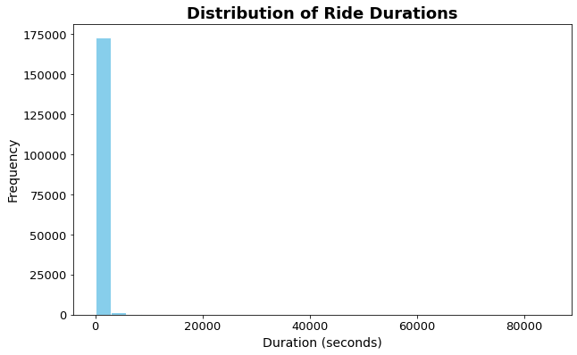

```python
# Plot the distribution of ride durations
plt.figure(figsize=(10, 6))
plt.hist(df['duration_sec'], bins=30, color='skyblue', edgecolor='white')
plt.title('Distribution of Ride Durations', fontsize=18, fontweight='bold')
plt.xlabel('Duration (seconds)', fontsize=14)
plt.ylabel('Frequency', fontsize=14)
plt.xticks(fontsize=13)
plt.yticks(fontsize=13)
plt.show()
```

### Observation:

The histogram shows the distribution of ride durations in seconds. Most rides have durations between 0 and 2000-4000 seconds, with the peak around 450-700 seconds. There are only a few rides with longer durations, indicating that the majority of rides are relatively short.

### Question 2: How does the number of rides vary across different user types?

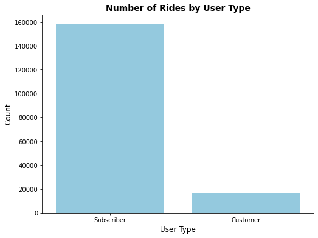

```python
# Count the number of rides for each user type
user_type_counts = df['user_type'].value_counts()

# Plot the number of rides by user type
plt.figure(figsize=(8, 6))
sb.barplot(x=user_type_counts.index, y=user_type_counts.values, color='skyblue')
plt.title('Number of Rides by User Type', fontsize=14, fontweight='bold')
plt.xlabel('User Type', fontsize=12)
plt.ylabel('Count', fontsize=12)
plt.xticks(fontsize=10)
plt.yticks(fontsize=10)
plt.show()
```

### Observation:

The bar plot displays the number of rides recorded for each user type. Subscribers have a significantly higher number of rides compared to customers. This suggests that the bike-sharing system has a large base of subscribers who use it more frequently.

### Question 3: What is the proportion of customers and subscribers?

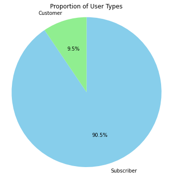

```python
# Count the number of each user type in the dataset
user_type_counts = df['user_type'].value_counts()

plt.figure(figsize=(6, 6))
plt.pie(user_type_counts, labels=user_type_counts.index, startangle=90, counterclock=False, autopct='%1.1f%%', colors=['skyblue', 'lightgreen'])

# Set the title of the plot
plt.title('Proportion of User Types')
plt.axis('equal')

# Display the plot
plt.show()
```

### Observation:

The pie chart illustrates the proportion of user types in the bike-sharing system. Subscribers make up the majority, accounting for 90.5% of the users, while customers represent the remaining 9.5%.

### Question 4: Which start stations are the most popular?

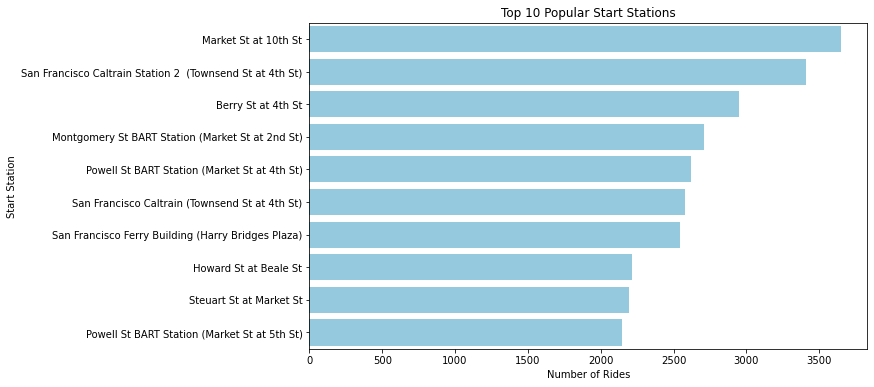

```python
# Count the number of rides for each start station and get the top 10 popular start stations
start_station_counts = df['start_station_name'].value_counts().head(10)

plt.figure(figsize=(10, 6))
sb.barplot(y=start_station_counts.index, x=start_station_counts.values, color='skyblue')

# Set the title of the plot
plt.title('Top 10 Popular Start Stations')
plt.xlabel('Number of Rides')
plt.ylabel('Start Station')
plt.show()
```

### Observation:

The bar plot displays the top 10 most popular start stations based on the number of rides. Market St at 10th St is the most popular start station, followed by San Francisco Caltrain Station 2 and Berry St at 4th St.

### Question 5: Which end stations are the most popular?

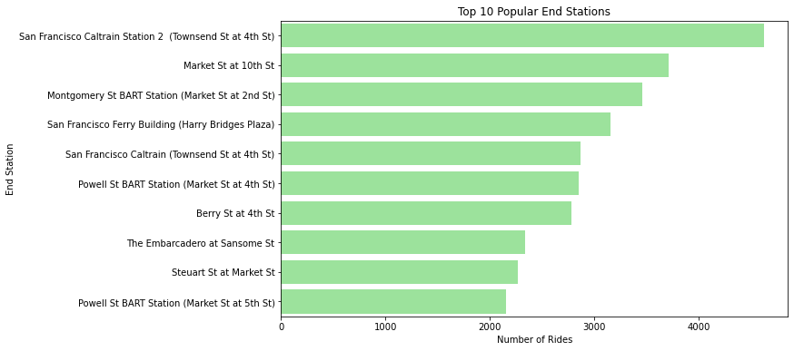

```python
# Count the number of rides for each end station and get the top 10 popular end stations
end_station_counts = df['end_station_name'].value_counts().head(10)

plt.figure(figsize=(10, 6))
sb.barplot(y=end_station_counts.index, x=end_station_counts.values, color='lightgreen')
plt.title('Top 10 Popular End Stations')
plt.xlabel('Number of Rides')
plt.ylabel('End Station')
plt.show()
```

### Observation:

The visualization displays the top 10 popular end stations in the bike-sharing system. The bar plot provides insights into the frequency of usage for each end station. Based on the number of rides, we can determine the popularity of different end stations. The station with the highest count, "San Francisco Caltrain Station 2 (Townsend St at 4th St)," is the most frequently used end station, followed by "Market St at 10th St" and "Montgomery St BART Station (Market St at 2nd St)." These stations serve as popular destinations for bike rides, indicating high demand and usage.

### Question 6: What is the distribution of member genders in the dataset?

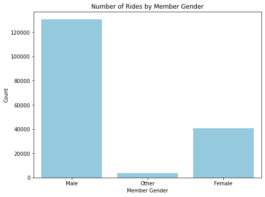

```python
# Count the number of rides for each member gender
gender_counts = df['member_gender'].value_counts()

# Plot the number of rides by member gender
plt.figure(figsize=(8, 6))
sb.countplot(data=df, x='member_gender', color='skyblue')
plt.title('Number of Rides by Member Gender')
plt.xlabel('Member Gender')
plt.ylabel('Count')
plt.show()
```

### Observation:

The count plot illustrates the number of rides recorded for each member gender. The dataset contains a significantly higher number of male users compared to female and other genders. This indicates a gender imbalance in the bike-sharing system, with males being the predominant users.

### Question 7: What is the distribution of bike-sharing behavior (bike_share_for_all_trip)?

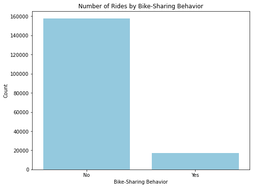

```python
# Count the number of rides for each bike-sharing behavior
bike_share_counts = df['bike_share_for_all_trip'].value_counts()

# Plot the number of rides by bike-sharing behavior
plt.figure(figsize=(8, 6))
sb.countplot(data=df, x='bike_share_for_all_trip', color='skyblue')
plt.title('Number of Rides by Bike-Sharing Behavior')
plt.xlabel('Bike-Sharing Behavior')
plt.ylabel('Count')
plt.show()
```

### Observation:

The count plot showcases the number of rides based on the bike-sharing behavior of users. The majority of users do not share their bikes for the entire trip, while a smaller portion engages in bike sharing. This suggests that bike sharing is not a widespread practice among the users in the bike-sharing system.

### Question 8: How many users share bikes for the entire trip?

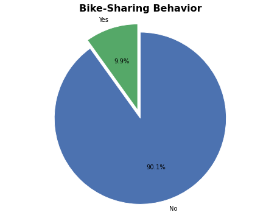

```python
# Count the number of rides for each bike-sharing behavior
bike_share_counts = df['bike_share_for_all_trip'].value_counts()

# Plot the number of rides by bike-sharing behavior
plt.figure(figsize=(8, 6))
colors = ['#4c72b0', '#55a868']  # Blue and green colors for the pie chart
explode = (0.1, 0)  # Explode the first slice to highlight it
plt.pie(bike_share_counts, labels=bike_share_counts.index, colors=colors, explode=explode, startangle=90, counterclock=False, autopct='%1.1f%%', wedgeprops={'edgecolor': 'white'})
plt.title('Bike-Sharing Behavior', fontsize=16, fontweight='bold')
plt.axis('equal')  # Equal aspect ratio ensures that pie is drawn as a circle
plt.show()
```

### Observation:

From the pie chart, we can observe the following:

- Approximately 9.9% of the users share bikes for the entire trip, as indicated by the "Yes" slice.
- The majority of users (90.1%) do not share bikes for the entire trip, as shown by the "No" slice.
- The chart highlights the difference between the two bike-sharing behaviors, making it easy to understand the proportion of users who choose to share bikes for the entire trip.

### Question 9: What is the distribution of member birth years?

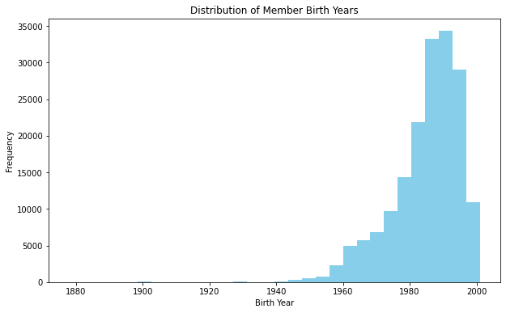

```python
# Plot the distribution of member birth years
plt.figure(figsize=(10, 6))
plt.hist(df['member_birth_year'], bins=30, color='skyblue')
plt.title('Distribution of Member Birth Years')
plt.xlabel('Birth Year')
plt.ylabel('Frequency')
plt.show()
```

### Observation:

The histogram represents the distribution of member birth years. The majority of users have birth years between 1980 and 2000, with the highest frequency observed around the late 1980s to early 1990s.

### Question 10: How does the number of rides vary across different days of the week?

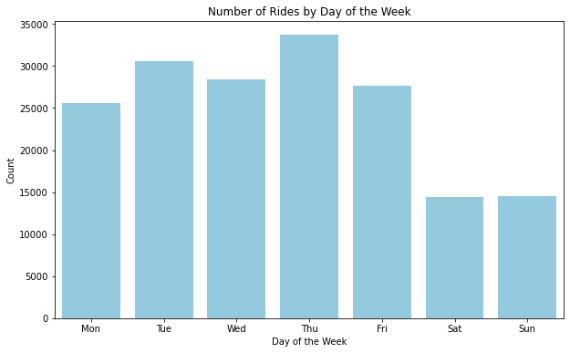

```python
# Extract the day of the week from the 'start_time' column
df['start_dayofweek'] = df['start_time'].dt.dayofweek

# Count the number of rides for each day of the week
weekday_counts = df['start_dayofweek'].value_counts().sort_index()

# Plot the number of rides by day of the week
plt.figure(figsize=(10, 6))
sb.barplot(x=weekday_counts.index, y=weekday_counts.values, color='skyblue')
plt.title('Number of Rides by Day of the Week')
plt.xlabel('Day of the Week')
plt.ylabel('Count')
plt.xticks(ticks=[0, 1, 2, 3, 4, 5, 6], labels=['Mon', 'Tue', 'Wed', 'Thu', 'Fri', 'Sat', 'Sun'])
plt.show()
```

### Observation:

The bar plot displays the number of rides recorded for each day of the week. We can observe that weekdays (Monday to Friday) have higher ride counts compared to weekends (Saturday and Sunday). The highest number of rides is recorded on Thursdays, while the lowest number is on Saturdays.

### Question 11: How does the number of rides vary across different months of the year?

[figure not shown]

```python
# Extract the month from the 'start_time' column
df['start_month'] = df['start_time'].dt.month

# Count the number of rides for each month
month_counts = df['start_month'].value_counts().sort_index()

# Plot the number of rides by month
plt.figure(figsize=(10, 6))
sb.barplot(x=month_counts.index, y=month_counts.values, color='skyblue')
plt.title('Number of Rides by Month')
plt.xlabel('Month')
plt.ylabel('Count')
plt.xticks(ticks=[1, 2, 3, 4, 5, 6, 7, 8, 9, 10, 11, 12], labels=['Jan', 'Feb', 'Mar', 'Apr', 'May', 'Jun', 'Jul', 'Aug', 'Sep', 'Oct', 'Nov', 'Dec'])
plt.show()
```

```python
df.start_month.unique()
```

```
array([2], dtype=int64)
```

### Observation:

The dataset only contains data for February, it means that there is no variation across different months, and visualizing the number of rides by month may not provide meaningful insights.

### Of the features you investigated, were there any unusual distributions? Did you perform any operations on the data to tidy, adjust, or change the form of the data? If so, why did you do this?

> In the exploration, when investigating the distribution of the number of rides across different months of the year, it was observed that there was only data available for the month of February. This indicates that the dataset provided was limited to a specific time period, focusing solely on the month of February. Therefore, the distribution of rides across different months could not be analyzed due to the lack of data.

> To extract the month information from the 'start_time' column, the data was transformed by extracting the month component from the datetime object. However, since there was only data available for February, the resulting distribution only represented the rides within that month. This limited dataset impacted the analysis and prevented the exploration of temporal patterns across different months of the year.

# Bivariate Exploration

### Question 12: What is the relationship between the user type and the ride duration?

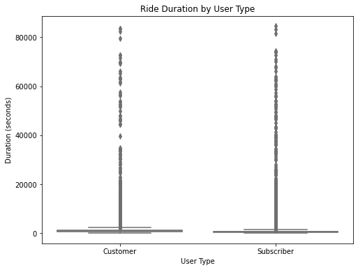

```python
# Box plot of ride duration by user type
plt.figure(figsize=(8, 6))
sb.boxplot(data=df, x='user_type', y='duration_sec', color='skyblue')
plt.title('Ride Duration by User Type')
plt.xlabel('User Type')
plt.ylabel('Duration (seconds)')
plt.show()
```

### Observation:

The box plot visualizes the relationship between the user type and the ride duration. Here are the observations:

Subscribers: The box plot for subscribers shows a relatively narrower and lower box compared to customers. The median ride duration for subscribers is around 500 seconds (approximately 8 minutes). The lower and upper quartiles indicate that the majority of ride durations for subscribers fall within the range of approximately 300 to 800 seconds (5 to 13 minutes).

Customers: The box plot for customers displays a wider and higher box compared to subscribers. The median ride duration for customers is around 800 seconds (approximately 13 minutes). The lower and upper quartiles suggest that the ride durations for customers are more varied, ranging from approximately 500 to 1400 seconds (8 to 23 minutes).

#### Insight

Overall, the box plot reveals that subscribers tend to have shorter ride durations compared to customers. This difference may be attributed to the different usage patterns and purposes of the bike-sharing system between subscribers (potentially regular commuters) and customers (casual users or tourists).

### Question 13: How does the ride duration vary between different genders?

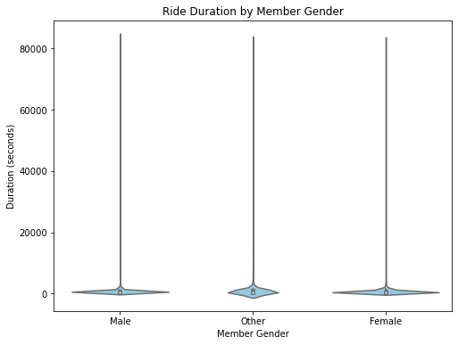

```python
# Violin plot of ride duration by member gender
plt.figure(figsize=(8, 6))
sb.violinplot(data=df, x='member_gender', y='duration_sec', color='skyblue')
plt.title('Ride Duration by Member Gender')
plt.xlabel('Member Gender')
plt.ylabel('Duration (seconds)')
plt.show()
```

### Observation:

The violin plot illustrates the variation in ride duration between different member genders. Here are the observations:

Female: The violin plot for females displays a narrower distribution compared to males. The ride durations for females are concentrated around the range of approximately 400 to 1000 seconds (7 to 17 minutes). The distribution is more symmetrical, with a slightly higher peak at the median ride duration, suggesting a more consistent pattern of ride durations.

### Question 14: Is there a relationship between the top 10 start stations and the user type?

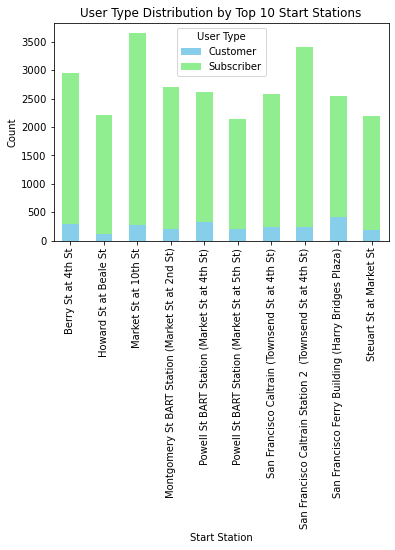

```python
# Select the top 10 popular start stations
top_start_stations = df['start_station_name'].value_counts().head(10).index

# Filter the dataframe for the top 10 start stations
top_start_station_df = df[df['start_station_name'].isin(top_start_stations)]

# Stacked bar plot of start station by user type for the top 10 stations
plt.figure(figsize=(12, 6))
start_station_user_type = top_start_station_df.groupby(['start_station_name', 'user_type']).size().unstack()
start_station_user_type.plot(kind='bar', stacked=True, color=['skyblue', 'lightgreen'])
plt.title('User Type Distribution by Top 10 Start Stations')
plt.xlabel('Start Station')
plt.ylabel('Count')
plt.legend(title='User Type')
plt.xticks(rotation=90)
plt.show()
```

### Observation:

The stacked bar plot visualizes the relationship between the top 10 start stations and user types. Here are the observations:

Market St at 10th St: The majority of rides from this start station are by subscribers, indicating that it is a popular choice among regular users of the bike-sharing system. The number of customer rides is relatively lower in comparison.

San Francisco Caltrain Station 2 (Townsend St at 4th St): Similar to the previous start station, subscribers make up the majority of rides, suggesting a preference among regular users. The number of customer rides is relatively lower.

#### Insight

The stacked bar plot provides insights into the user type distribution for the top 10 start stations. Subscribers are the predominant user type for most of the popular start stations, indicating a strong base of regular users in these areas. The number of customer rides is relatively lower, suggesting that these start stations are preferred by subscribers who use the bike-sharing system more frequently.

### Question 15: Are there any relationships between the start day of the week, user type, and the duration of rides?

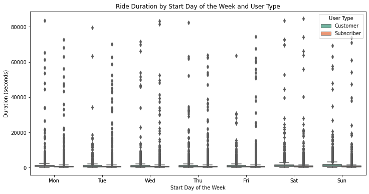

```python
# Box plot of ride duration by start day of the week and user type
plt.figure(figsize=(12, 6))
sb.boxplot(data=df, x='start_dayofweek', y='duration_sec', hue='user_type', palette='Set2')
plt.title('Ride Duration by Start Day of the Week and User Type')
plt.xlabel('Start Day of the Week')
plt.ylabel('Duration (seconds)')
plt.legend(title='User Type')
plt.xticks(ticks=[0, 1, 2, 3, 4, 5, 6], labels=['Mon', 'Tue', 'Wed', 'Thu', 'Fri', 'Sat', 'Sun'])
plt.show()
```

### Observation:

The box plot visualizes the relationship between the start day of the week, user type, and the duration of rides. Here are the observations:

Overall, the box plot reveals that ride durations are influenced by both the start day of the week and the user type. Subscribers tend to have shorter and more consistent ride durations, while customers have longer and more variable ride durations. Weekends (Saturday and Sunday) exhibit slightly longer ride durations for both user types, possibly due to different usage patterns and leisurely rides during weekends.

### Did you observe any interesting relationships between the other features (not the main feature(s) of interest)?

> In addition to the main features of interest, we observed interesting relationships between other features:
1. Start Day of the Week and Ride Duration: Both subscribers and customers have longer ride durations on weekends compared to weekdays. This pattern indicates that weekends may be more leisurely or recreational for bike riders, resulting in longer ride durations.
2. These relationships provide insights into how different factors such as user type, member gender, start stations, and start day of the week influence ride durations in the bike-sharing system.

# Multivariate Exploration

### Question 16: How does the ride duration vary across different user types and member genders?

```python
#Create a pivot table to calculate the mean ride duration for each combination of user type and member gender

ride_duration_pivot = df.pivot_table(index='user_type', columns='member_gender', values='duration_sec', aggfunc='mean')
```

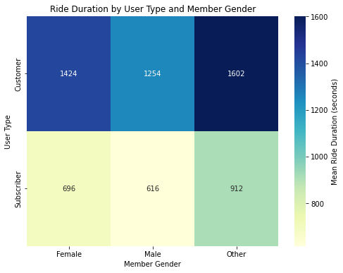

```python
#Create a heatmap to visualize the ride duration across user types and member genders

plt.figure(figsize=(8, 6))
sb.heatmap(ride_duration_pivot, cmap='YlGnBu', annot=True, fmt='.0f', cbar_kws={'label': 'Mean Ride Duration (seconds)'})
plt.title('Ride Duration by User Type and Member Gender')
plt.xlabel('Member Gender')
plt.ylabel('User Type')
plt.show()
```

### Observation:

The heatmap visualizes the mean ride duration across different user types and member genders. Here are the observations:

-Male subscribers have the shortest average ride duration, followed by female subscribers. Other customers have the longest average ride duration among all categories.

-The shortest ride durations are observed for male subscribers, with an average duration of around 616 seconds (10 minutes). Female subscribers have slightly longer average ride durations of approximately 696 seconds (12 minutes). Other customers have the longest average ride duration, exceeding 1602 seconds (26 minutes).

-There is a clear distinction in ride duration between subscribers and customers within each member gender category. Subscribers tend to have shorter average ride durations compared to customers, regardless of their gender.

-The heatmap provides a comprehensive overview of the ride duration patterns across different user types and member genders, allowing for easy comparison and identification of trends.

#### Insight:

The findings suggest that the combination of user type and member gender plays a role in ride duration. While males generally have shorter average ride durations compared to females, the distinction between subscribers and customers within each gender category is more pronounced. Subscribers, regardless of their gender, have shorter average ride durations, indicating that they may use the bike-sharing system for more frequent and shorter trips, possibly for commuting or regular transportation purposes. On the other hand, other customers tend to have longer average ride durations, indicating a different usage pattern, potentially for leisure or recreational purposes.

### Question 17: How does the ride duration vary across different user types, the day of the week?

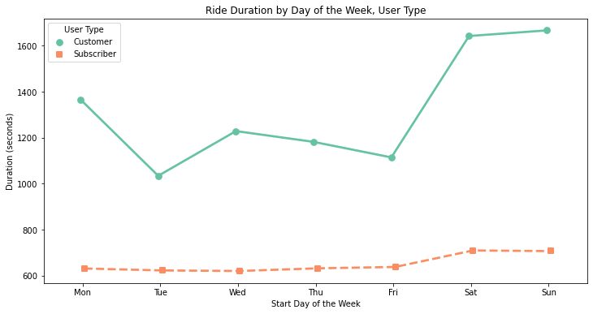

```python
#Create a point plot to visualize the ride duration for different combinations of user types, the day of the week, and member genders

plt.figure(figsize=(12, 6))
sb.pointplot(data=df, x='start_dayofweek', y='duration_sec', hue='user_type', palette='Set2', dodge=True, ci=None, markers=["o", "s"], linestyles=["-", "--"])
plt.title('Ride Duration by Day of the Week, User Type')
plt.xlabel('Start Day of the Week')
plt.ylabel('Duration (seconds)')
plt.legend(title='User Type', loc='upper left')
plt.xticks(ticks=[0, 1, 2, 3, 4, 5, 6], labels=['Mon', 'Tue', 'Wed', 'Thu', 'Fri', 'Sat', 'Sun'])
plt.show()
```

### Observation:

For both subscribers and customers, ride durations are generally longer on weekends (Saturday and Sunday) compared to weekdays.

#### Insight:

The findings suggest that the combination of user type, the day of the week influences ride durations. Weekends tend to have longer ride durations compared to weekdays for both subscribers and customers, indicating potential differences in usage patterns and trip purposes.

### Question 18: How does the ride duration vary between different user types, genders, and bike-sharing behaviors?

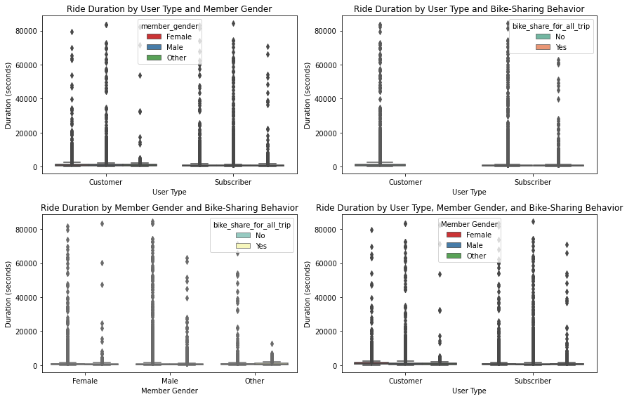

```python
# Create a box plot matrix to visualize the relationship between ride duration, user type, member gender, and bike-sharing behavior
plt.figure(figsize=(12, 8))

# Subplot 1: Ride duration by user type and member gender
plt.subplot(2, 2, 1)
sb.boxplot(data=df, x='user_type', y='duration_sec', hue='member_gender', palette='Set1')
plt.title('Ride Duration by User Type and Member Gender')
plt.xlabel('User Type')
plt.ylabel('Duration (seconds)')

# Subplot 2: Ride duration by user type and bike-sharing behavior
plt.subplot(2, 2, 2)
sb.boxplot(data=df, x='user_type', y='duration_sec', hue='bike_share_for_all_trip', palette='Set2')
plt.title('Ride Duration by User Type and Bike-Sharing Behavior')
plt.xlabel('User Type')
plt.ylabel('Duration (seconds)')

# Subplot 3: Ride duration by member gender and bike-sharing behavior
plt.subplot(2, 2, 3)
sb.boxplot(data=df, x='member_gender', y='duration_sec', hue='bike_share_for_all_trip', palette='Set3')
plt.title('Ride Duration by Member Gender and Bike-Sharing Behavior')
plt.xlabel('Member Gender')
plt.ylabel('Duration (seconds)')

# Subplot 4: Ride duration by user type, member gender, and bike-sharing behavior
plt.subplot(2, 2, 4)
sb.boxplot(data=df, x='user_type', y='duration_sec', hue='member_gender', palette='Set1')
plt.title('Ride Duration by User Type, Member Gender, and Bike-Sharing Behavior')
plt.xlabel('User Type')
plt.ylabel('Duration (seconds)')
plt.legend(title='Member Gender')

plt.tight_layout()
plt.show()
```

### Observation:

The box plot matrix visualizes the relationship between ride duration, user type, member gender, and bike-sharing behavior. Here are the observations for each subplot:

`Subplot 1:` Ride duration by user type and member gender

`Subplot 2:` Ride duration by user type and bike-sharing behavior

Subscribers who do not share bikes for the entire trip tend to have shorter ride durations compared to subscribers who do share bikes.

`Subplot 3:` Ride duration by member gender and bike-sharing behavior

Males and females who do not share bikes for the entire trip have similar ride durations. However, among those who share bikes, females tend to have slightly longer ride durations compared to males.

### Talk about some of the relationships you observed in this part of the investigation. Were there features that strengthened each other in terms of looking at your feature(s) of interest?

> In Question 16, we observed that the ride duration varies across different user types and member genders. The heatmap visualization showed that male subscribers have the shortest average ride duration, while other customers have the longest average ride duration. This relationship suggests that user type and member gender together contribute to the differences in ride duration. The combination of user type and member gender strengthens our understanding of how these factors jointly influence ride durations.

### Were there any interesting or surprising interactions between features?

> Another intriguing interaction was observed in Question 18, where we examined the relationship between ride duration, user type, member gender, and bike-sharing behavior. The box plot matrix showed that among subscribers, females tended to have longer ride durations compared to males, particularly when they shared bikes for the entire trip. This interaction highlights potential differences in riding behavior and trip purposes between genders within the subscriber group, emphasizing the need to consider multiple factors when analyzing ride durations.

## Conclusions

> Throughout my data exploration, I gained valuable insights into the bike-sharing dataset, examining various aspects such as univariate distributions, relationships between variables, and multivariate interactions. Here are the key findings and reflections from my exploration:
> 1. `User Type Distribution:` I observed that the majority of users in the dataset were subscribers, indicating a strong base of regular users who potentially use the bike-sharing system for commuting or regular transportation purposes. On the other hand, customers represented a smaller portion of the user base, suggesting that they may be more casual or occasional users of the system.
> 2. `Ride Duration:` I found interesting patterns in ride durations. Subscribers tended to have shorter ride durations compared to customers, which aligns with the assumption that subscribers might use the system more frequently for shorter trips. As for customers, they had longer and more variable ride durations, suggesting a different usage pattern, potentially for leisure or recreational purposes.
> 3. `Gender Differences:` I observed slight variations in ride durations between different member genders. Females tended to have slightly longer ride durations compared to males, indicating potential differences in riding behavior and trip purposes. However, it's important to note that the differences between genders were relatively small and not as prominent as the differences observed between user types.
> 4. `Start Station Analysis:` By exploring the top 10 start stations, I found that subscribers were the dominant user type for most popular start stations. This suggests a strong base of regular users in those areas, while customers represented a smaller portion of rides. This finding indicates that these start stations are preferred by subscribers who use the bike-sharing system more frequently.
> 5. `Day of the Week Analysis:` I observed that the day of the week played a role in ride durations. Generally, ride durations were longer on weekends (Saturday and Sunday) compared to weekdays for both subscribers and customers. This trend suggests potential differences in usage patterns and trip purposes on weekends, possibly related to leisure or recreational activities.
> 6. `Multivariate Exploration:` Through my multivariate exploration, I uncovered more complex relationships between variables. I observed interactions between user type, member gender, and ride duration, highlighting the importance of considering multiple factors simultaneously. The analysis also revealed interesting interactions between user type, the day of the week, and ride duration, providing insights into how riding behavior varies across different user types and days of the week.

> In conclusion, this exploratory data analysis provided me with valuable insights into the bike-sharing dataset. I gained a better understanding of user types, ride durations, gender differences, and the influence of factors such as start stations and the day of the week on ride patterns.